Aurélien Nicosia · Université Laval

# À propos

Un parcours entre recherche et enseignement.

Mon profil, mes expériences en science des données et mes activités universitaires, avec les coordonnées pour me joindre.

## Profil

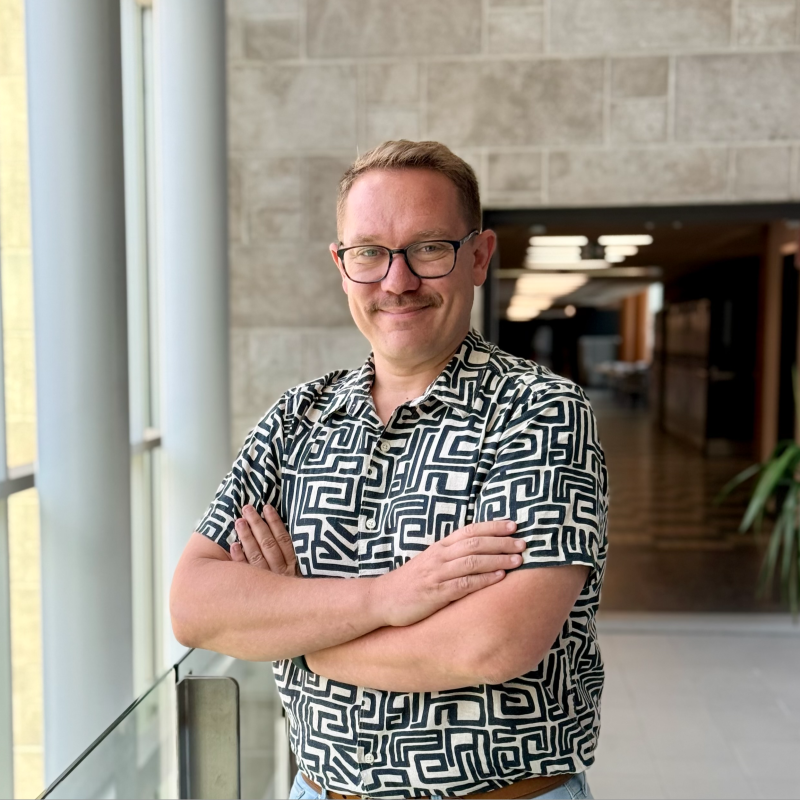

Je suis chargé d’enseignement en mathématiques et statistiques au Département de mathématiques et de statistique de l’Université Laval, à Québec. Je coordonne aussi le Centre de Dépannage et d’Apprentissage en mathématiques et statistique, un service de soutien à la réussite destiné aux étudiantes et étudiants de plusieurs cours du Département.

Titulaire d’un doctorat en statistique de l’Université Laval (2024), je développe des méthodes de diagnostic et de quantification de l’incertitude pour les modèles à états latents, les données directionnelles et l’estimation de densité. Mes travaux associent recherche méthodologique, simulation, visualisation et logiciels R reproductibles.

Avant mon poste actuel, j’ai été consultant en statistique à l’Université Laval (2014-2017), gestionnaire en science des données chez GSK Canada (2017-2020), puis directeur de la recherche et de l’innovation analytique chez Co-operators (2020-2022). J’enseigne également à l’UQAC depuis 2021. Ces expériences nourrissent mon approche des collaborations, de la formation et de la traçabilité des analyses.

Mon enseignement couvre la statistique, les probabilités, la science des données et la programmation, ainsi que la gestion de projets au deuxième cycle, en français et en anglais. J’accorde une place centrale à la compréhension des méthodes, à la reproductibilité et à l’accompagnement humain.

### Enseignement

Conception de cours en statistique, science des données et programmation R, avec une attention particulière à l’apprentissage actif, aux études de cas réalistes et aux rapports reproductibles.

### Recherche

Développement de méthodes et de logiciels pour l’estimation de densité, les modèles multi-états, les données circulaires, les modèles de Markov cachés et l’analyse du mouvement animalier.

### Outils numériques

Création de packages R, plateformes Quarto, tutoriels interactifs et ressources ouvertes pour soutenir la recherche reproductible et l’enseignement de la science des données.

### Innovation pédagogique

Intégration raisonnée d’outils numériques et d’assistants conversationnels dans des dispositifs encadrés, avec maintien du rôle central de l’accompagnement humain.

## Réalisations récentes

- Développement du GPT-CDA, présenté dans [ULaval Nouvelles le 22 mai 2026](https://nouvelles.ulaval.ca/2026/05/22/le-gpt-cda-un-robot-conversationnel-qui-epaule-les-etudiantes-et-etudiants-dans-les-cours-de-mathematiques-et-de-statistique-66c35c61-4649-41a0-befb-c2f79036ac30).
- Publication de [Beyond the next step: A multi-criteria generative validation framework for step selection functions](https://doi.org/10.1111/2041-210X.70313) dans Methods in Ecology and Evolution.
- Mise à disposition de packages R récents sur le CRAN, dont GLBFP, DonutMap, ggcircular, CircularRegression et tutorizeR.
- Animation d’un atelier sur l’IA et l’enseignement à SSC 2026, accompagné d’une [galerie publique de ressources pédagogiques](https://aureliennicosiaulaval.github.io/ssc-2026-ai-teaching-gallery/).
- Prix 2026 de la présentation par un nouveau chercheur à SSC 2026 pour une présentation sur LOO-LBFP.

## Contact

Université Laval, Département de mathématiques et de statistique

Québec, QC, Canada

aurelien.nicosia@mat.ulaval.ca

## À propos du site

Ce site est généré avec [Quarto](https://quarto.org) et déployé avec GitHub Pages. Il rassemble mes activités de recherche, d’enseignement, de développement logiciel et d’innovation pédagogique. Le dépôt source est accessible depuis la barre de navigation.

Les corrections et suggestions sont bienvenues par l’interface GitHub du site ou par courriel.